[figure not shown]

# Text as data: from words to predictions

MY202 · Lab 9

Jonas Weinert

Department of Methodology | London School of Economics and Political Science

25 November 2026

## Lab overview

| Part | Topic | Notebook | Mode | Time |
| --- | --- | --- | --- | --- |
|  | Setup, and how a model can use text at all | lines 20–63 | together | 6 min |
| I | **Text to a table**: corpus, tokens, document-feature matrix | lines 65–164 | concept → run together → your turn | 32 min |
| II | **Which words tell them apart?** Keyness and word pairs | lines 166–224 | concept → run together | 12 min |
| III | **Predict and explain**: TF-IDF, boosted trees, importance and SHAP | lines 226–388 | concept → run together → your turn | 35 min |
|  | Wrap-up |  |  | 4 min |

So far every column was a number or a category. Today the data are 1,986 **reviews of GP practices**, written in plain English. Step one is new: turn text into columns. Step two is Lab 5 again: a split, a recipe, boosted trees.

## Can a model read?

Text as dataI · Text to tableII · Which words?III · Predict, explainWrap-up

Six reviews of a café (made up)

happy

Great coffee, and the staff are so friendly!

happy

Friendly staff. The coffee was great.

happy

I love the cakes and the coffee here.

unhappy

The coffee was cold and the staff were rude.

unhappy

We had to wait 20 minutes for a cold coffee.

unhappy

Rude staff, and a long wait. Never again!

Which customers were happy?

How did you know?

You looked for words Some words are only in happy reviews, others only in unhappy ones.

And you ignored *coffee* It is in five of the six reviews, so it tells you nothing.

So: one column per word A model needs numbers. Count each word in each review: a **bag of words**.

# Text to a table

Part I

Corpus · tokens · document-feature matrix

## From six reviews to a table, in four steps

Text as dataI · Text to tableII · Which words?III · Predict, explainWrap-up

1 · A corpus: six documents, each with what we know about it

happy

Great coffee, and the staff are so friendly!

happy

Friendly staff. The coffee was great.

happy

I love the cakes and the coffee here.

unhappy

The coffee was cold and the staff were rude.

unhappy

We had to wait 20 minutes for a cold coffee.

unhappy

Rude staff, and a long wait. Never again!

2 · Tokens: cut every review into pieces

happy

Greatcoffee,andthestaffaresofriendly!

happy

Friendlystaff.Thecoffeewasgreat.

happy

Ilovethecakesandthecoffeehere.

unhappy

Thecoffeewascoldandthestaffwererude.

unhappy

Wehadtowait20minutesforacoldcoffee.

unhappy

Rudestaff,andalongwait.Neveragain!

3 · Clean: drop punctuation, numbers and stopwords

happy

Greatcoffee,andthestaffaresofriendly!

happy

Friendlystaff.Thecoffeewasgreat.

happy

Ilovethecakesandthecoffeehere.

unhappy

Thecoffeewascoldandthestaffwererude.

unhappy

Wehadtowait20minutesforacoldcoffee.

unhappy

Rudestaff,andalongwait.Neveragain!

4 · Count: one row per review, one column per word

|  | coffee | staff | great | friendly | cold | rude | wait | love | cakes | minutes | long | never |
| --- | --- | --- | --- | --- | --- | --- | --- | --- | --- | --- | --- | --- |
| happy | 1 | 1 | 1 | 1 | 0 | 0 | 0 | 0 | 0 | 0 | 0 | 0 |
| happy | 1 | 1 | 1 | 1 | 0 | 0 | 0 | 0 | 0 | 0 | 0 | 0 |
| happy | 1 | 0 | 0 | 0 | 0 | 0 | 0 | 1 | 1 | 0 | 0 | 0 |
| unhappy | 1 | 1 | 0 | 0 | 1 | 1 | 0 | 0 | 0 | 0 | 0 | 0 |
| unhappy | 1 | 0 | 0 | 0 | 1 | 0 | 1 | 0 | 0 | 1 | 0 | 0 |
| unhappy | 0 | 1 | 0 | 0 | 0 | 1 | 1 | 0 | 0 | 0 | 1 | 1 |

Corpusthe texts and their labels

Tokenswords, numbers, punctuation

Cleankeep what carries meaning stopwords: the, and, was, a …

DFMdocument-feature matrix

Now it is a table 6 rows, 12 columns, mostly zeros. *Rude* and *rude* share a column.

## What the table forgets

Text as dataI · Text to tableII · Which words?III · Predict, explainWrap-up

A seventh review arrives

?

“Not friendly at all.”

|  | coffee | staff | great | friendly | cold | rude | wait | love | cakes | minutes | long | never |
| --- | --- | --- | --- | --- | --- | --- | --- | --- | --- | --- | --- | --- |
| happy | 1 | 1 | 1 | 1 | 0 | 0 | 0 | 0 | 0 | 0 | 0 | 0 |
| happy | 1 | 1 | 1 | 1 | 0 | 0 | 0 | 0 | 0 | 0 | 0 | 0 |
| happy | 1 | 0 | 0 | 0 | 0 | 0 | 0 | 1 | 1 | 0 | 0 | 0 |
| unhappy | 1 | 1 | 0 | 0 | 1 | 1 | 0 | 0 | 0 | 0 | 0 | 0 |
| unhappy | 1 | 0 | 0 | 0 | 1 | 0 | 1 | 0 | 0 | 1 | 0 | 0 |
| unhappy | 0 | 1 | 0 | 0 | 0 | 1 | 1 | 0 | 0 | 0 | 1 | 1 |
| ? | ? | ? | ? | ? | ? | ? | ? | ? | ? | ? | ? | ? |

What is left of it: one word

unhappy

Notfriendlyatall.

|  | coffee | staff | great | friendly | cold | rude | wait | love | cakes | minutes | long | never |
| --- | --- | --- | --- | --- | --- | --- | --- | --- | --- | --- | --- | --- |
| happy | 1 | 1 | 1 | 1 | 0 | 0 | 0 | 0 | 0 | 0 | 0 | 0 |
| happy | 1 | 1 | 1 | 1 | 0 | 0 | 0 | 0 | 0 | 0 | 0 | 0 |
| happy | 1 | 0 | 0 | 0 | 0 | 0 | 0 | 1 | 1 | 0 | 0 | 0 |
| unhappy | 1 | 1 | 0 | 0 | 1 | 1 | 0 | 0 | 0 | 0 | 0 | 0 |
| unhappy | 1 | 0 | 0 | 0 | 1 | 0 | 1 | 0 | 0 | 1 | 0 | 0 |
| unhappy | 0 | 1 | 0 | 0 | 0 | 1 | 1 | 0 | 0 | 0 | 1 | 1 |
| unhappy | 0 | 0 | 0 | 1 | 0 | 0 | 0 | 0 | 0 | 0 | 0 | 0 |

Fill in its row. Which columns get a 1?

Only *friendly* *not*, *at* and *all* are stopwords. The row looks like a happy customer’s.

The order is gone too “Rude staff, great coffee” and “great staff, rude coffee”: the same row. Hence **bag**.

Every step was a choice Which stopwords, which symbols, which words to keep: you decide, and it changes the result.

## The data: reviews of GP practices

Text as dataI · Text to tableII · Which words?III · Predict, explainWrap-up

**Notebook** lines 46–63 "create a tibble called nhs_reviews": the chunk is empty*code together*

nhs_reviews <- read_csv("data/NHS-reviews.csv") |> drop_na(review_positive)

1. **Keep the result** under this name.
2. **Read a CSV file** into a tibble.
3. **Where the file is**: in the `data` folder.
4. **The pipe**: pass it on.
5. **Drop rows** with a missing value …
6. … **in this column**: the outcome.

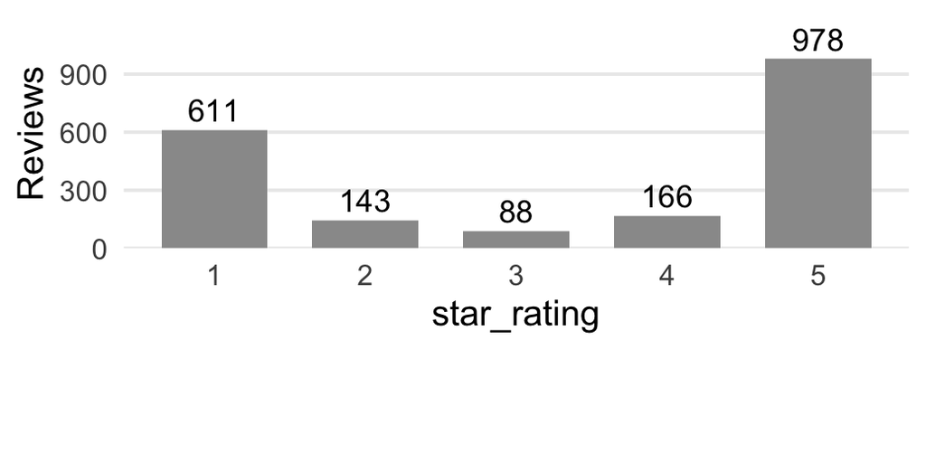

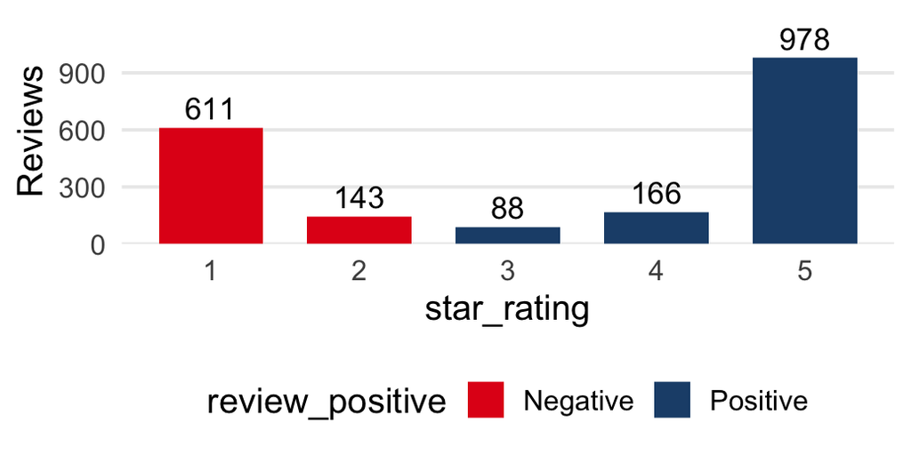

Which of these are “positive” reviews?

`review_positive`: the outcome Made from the stars: 1 or 2 is negative (754), 3 to 5 positive (1,232). We predict it **from the words alone**.

## Corpus, then tokens

Text as dataI · Text to tableII · Which words?III · Predict, explainWrap-up

**Notebook** lines 65–113 "Introducing quanteda": given, ready to run*run together*

nhs_corpus <- corpus(nhs_reviews, text_field = "review_text") nhs_tokens <- tokens(nhs_corpus, remove_punct = TRUE, remove_symbols = TRUE, remove_numbers = TRUE) |> tokens_remove(pattern = stopwords("en"))

1. **Make a corpus.**
2. **The text column.**
3. **Cut into tokens.**
4. **Drop** `.` `,` `!` `?`
5. **Drop** `&` `£` `+` and emoji.
6. **Drop** `20`, `111`, `2021`.
7. **Then take out** …
8. … **the 175 stopwords.**

Review 3, cut into tokens

Ihavealwayshadanextremelygoodexperiencewithmysurgery.TheGP’s,PracticeManager,Nurses&Receptionistsareallhelpful&professional.

Ihavealwayshadanextremelygoodexperiencewithmysurgery.TheGP’s,PracticeManager,Nurses&Receptionistsareallhelpful&professional.

Which of these tokens will survive?

182,450 tokens → 80,209 More than half of everything written is punctuation or a stopword.

## The document-feature matrix

Text as dataI · Text to tableII · Which words?III · Predict, explainWrap-up

**Notebook** lines 115–142 the DFM, and the whole pipeline in one chunk*run together*

nhs_dfm <- nhs_tokens |> dfm() |> dfm_trim(min_termfreq = 12)

1. **Count**: one row per review, one column per word, lower case.
2. **Trim** the columns.
3. **Keep a word only if** it is used at least 12 times in all reviews together.

After dfm()1,986 rows × 7,560 columns

Used once3,918 of the words plesant, explination …

After trim1,986 rows × 1,033 columns

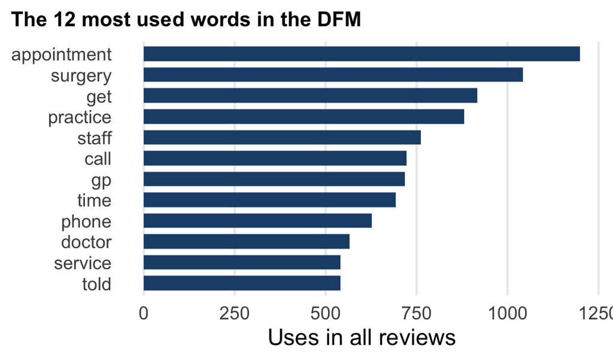

Why trim? A word used once cannot tell us anything about **other** reviews. And 97% of the cells are still 0.

## Your turn A: look at the words

Part I · lines 144–164 · in pairs

Syntax you need

```r
textplot_wordcloud(nhs_dfm)      # bigger = more frequent

tibble(
  ntoken = ntoken(nhs_tokens),   # tokens per review
  positive = docvars(nhs_tokens)$review_positive
) |>
  ggplot(aes(x = ___, fill = ___)) +
  geom_density(alpha = 0.5)      # alpha: see-through
```

- `ntoken()`: how many tokens each review has
- `docvars(...)$review_positive`: the label of each review
- `fill =` a column: one colour per group
- A box plot works too: `aes(positive, ntoken)` + `geom_boxplot()`

**Stuck?**

- Cloud unchanged in task 2: rerun the DFM chunk (117–126) as well
- `|>` error: the pipe goes at the **end** of the line before `ggplot(`

## Answers A: the word cloud

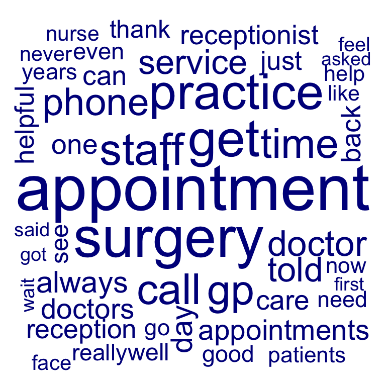

Stopwords removed

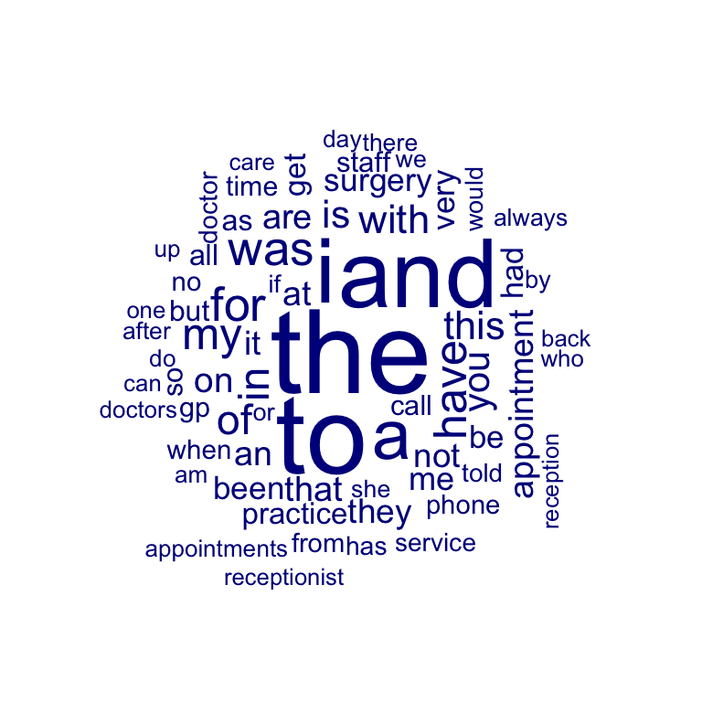

Stopwords left in

What the reviews are about Getting an **appointment**, the **phone**, the **staff**, the **doctor**. Not medicine: access and service.

With stopwords *the* 7,331, *to* 6,798, *and* 5,750 times. *appointment*: 1,199. The topic drowns.

A cloud shows frequency, only It cannot say which words go with **positive** reviews. That is Part II.

## Answers A: who writes more?

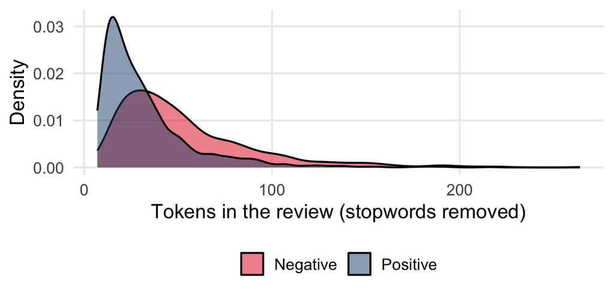

```r
tibble(
  ntoken = ntoken(nhs_tokens),
  positive = docvars(nhs_tokens)$review_positive
) |>
  ggplot(aes(ntoken, fill = positive)) +
  geom_density(alpha = 0.5)
```

Reading the code `ntoken` on the x-axis; `fill = positive` draws one curve per label; `alpha = 0.5` makes them see-through.

Negative reviews are longer Half of the negative reviews have more than 44 tokens. For positive reviews: 25.

A complaint tells a story “I called at 8, I was told …, then …”. Praise is short: “Friendly and helpful, thank you.”

# Which words tell them apart?

Part II

Keyness · and pairs of words

## Keyness: is a word where you would expect it?

Text as dataI · Text to tableII · Which words?III · Predict, explainWrap-up

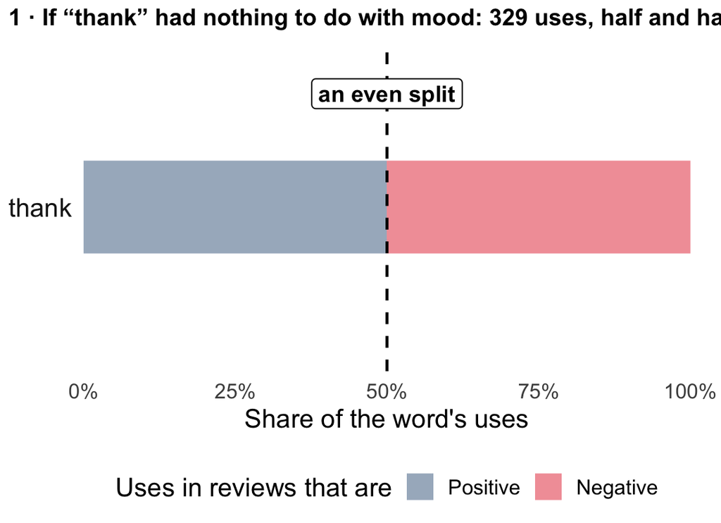

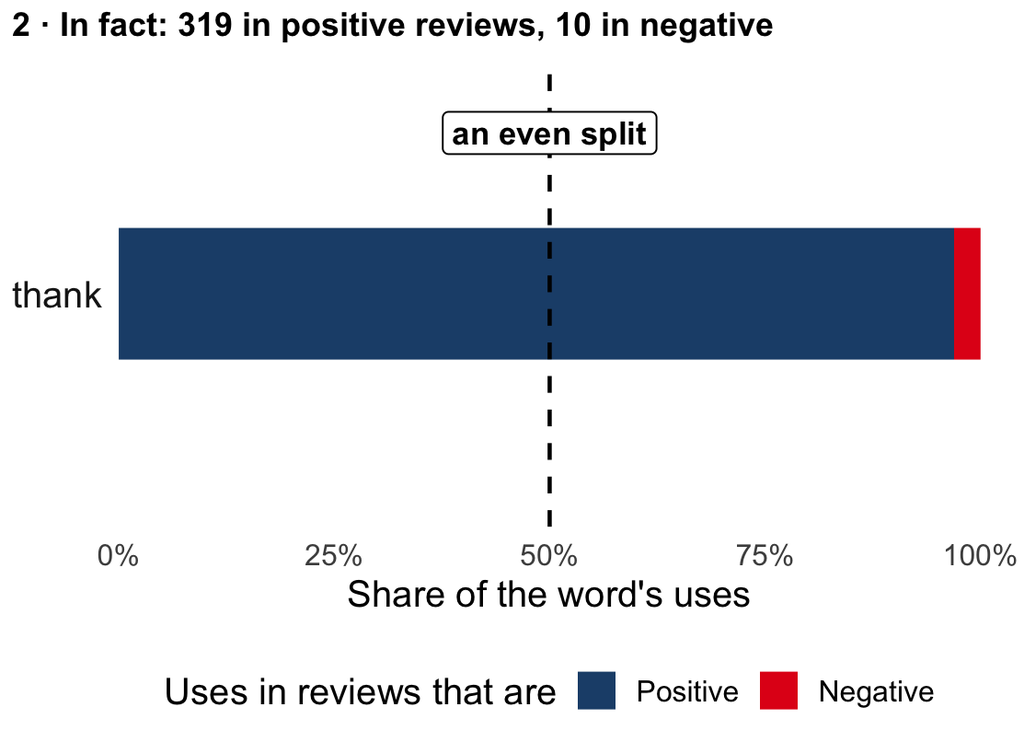

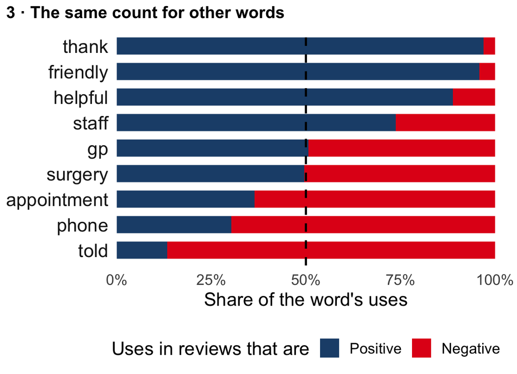

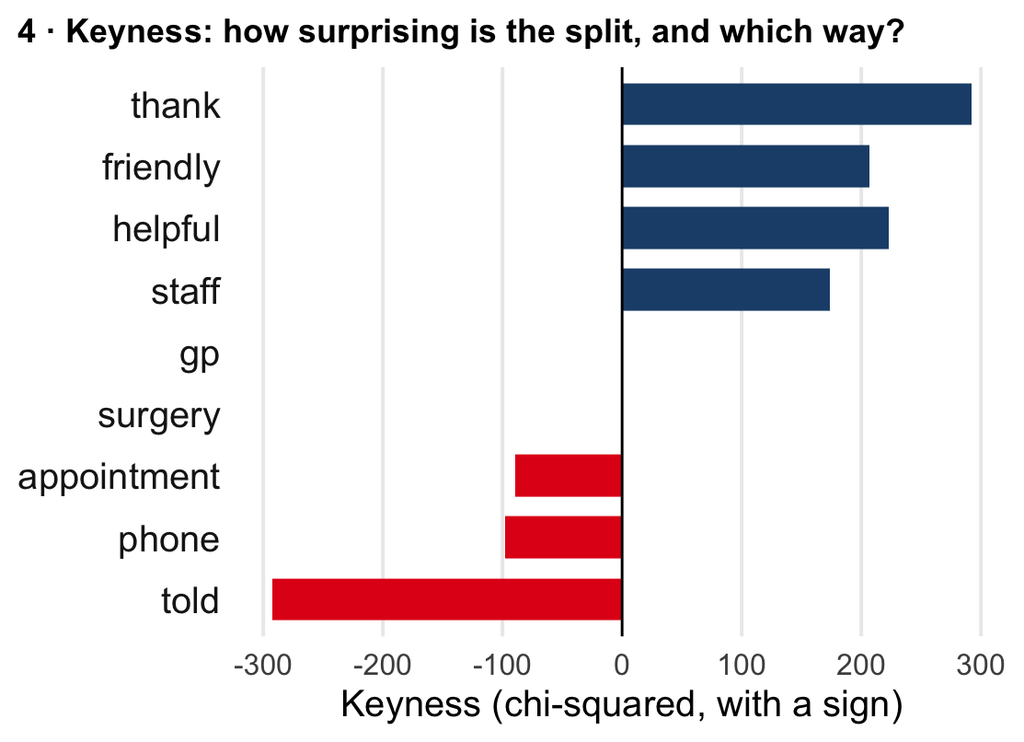

Expectedan even split both sides hold about 33,000 words

Observedwhere the uses really are

Keynesshow far apart the two are

Three kinds of word *thank*, *friendly*: nearly all in positive reviews. *told*: mostly in negative ones. *surgery*, *gp*: half and half.

One number per word A chi-squared test of the split. **Large** = far from even. The **sign** says which side: above 0 is typical of positive reviews.

## The keyness plot

Text as dataI · Text to tableII · Which words?III · Predict, explainWrap-up

**Notebook** lines 166–185 keyness, and the first classroom discussion*run together*

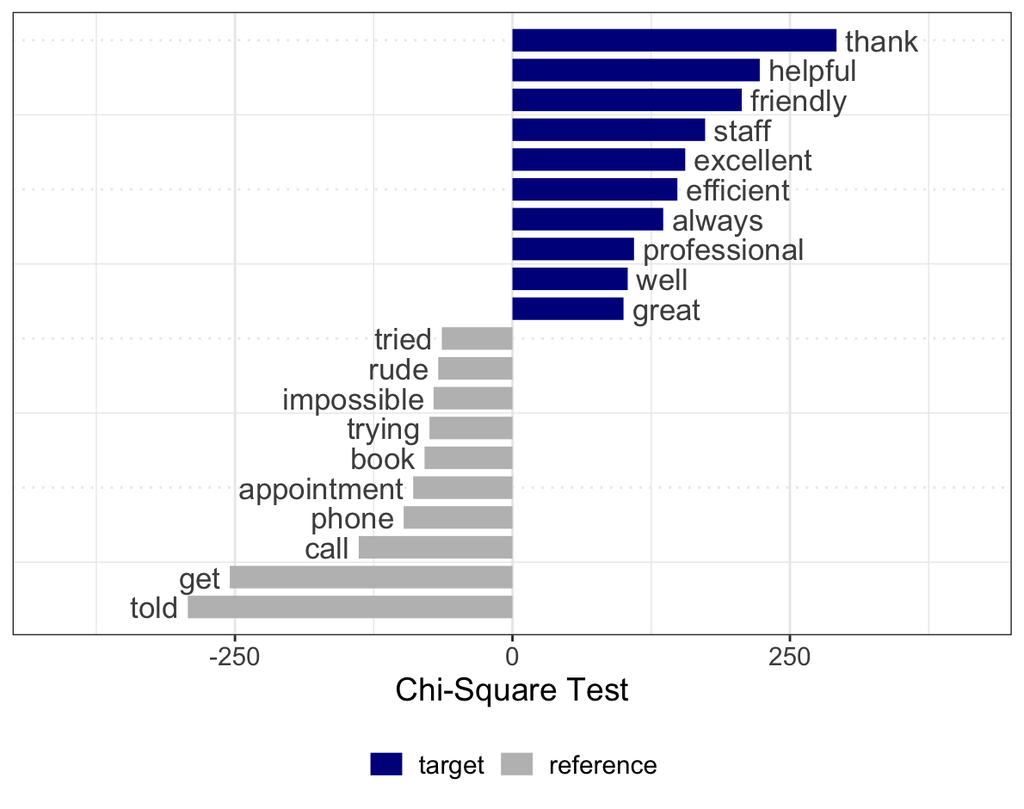

```r
positive_lgl <-
  docvars(nhs_dfm)$review_positive == "Positive"
tstat <- textstat_keyness(nhs_dfm,
                          target = positive_lgl)
```

What makes patients write a positive review? A negative one?

Positive: people *thank*, *helpful*, *friendly*, *staff*, *excellent*, *professional*. How they were treated.

Negative: access *told*, *get*, *call*, *phone*, *appointment*, *trying*, *impossible*. Getting through, and being sent away.

## Pairs of words: the bigram network

Text as dataI · Text to tableII · Which words?III · Predict, explainWrap-up

**Notebook** lines 187–224 the 60 most frequent pairs, drawn as a network*run together*

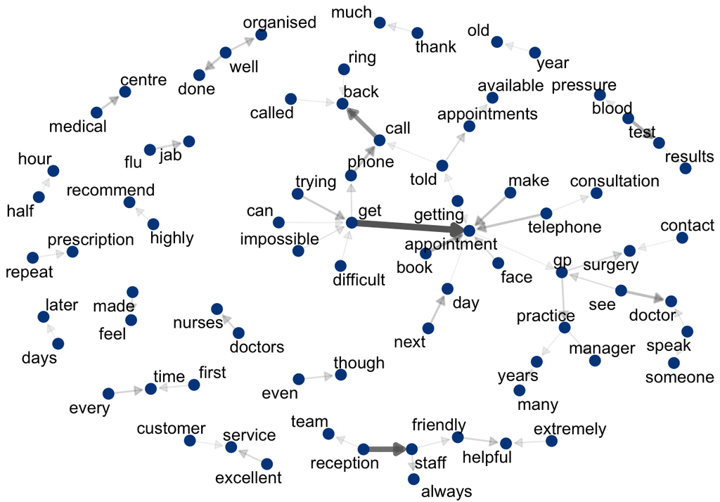

Bigramtwo tokens in a row "get appointment"

Arrowfirst word → second word

Thicka frequent pair

The hubs *appointment*: get, book, make, telephone (185 × “get appointment”). And *staff*: reception, friendly, helpful.

Why “face → face”? “Face **to** face”: *to* is a stopword and was removed first. 111 times.

# Predict and explain

Part III

TF-IDF · boosted trees · which words did the model use?

## From counts to TF-IDF

Text as dataI · Text to tableII · Which words?III · Predict, explainWrap-up

Café review 4: "The **coffee** was **cold** and the **staff** were **rude**."

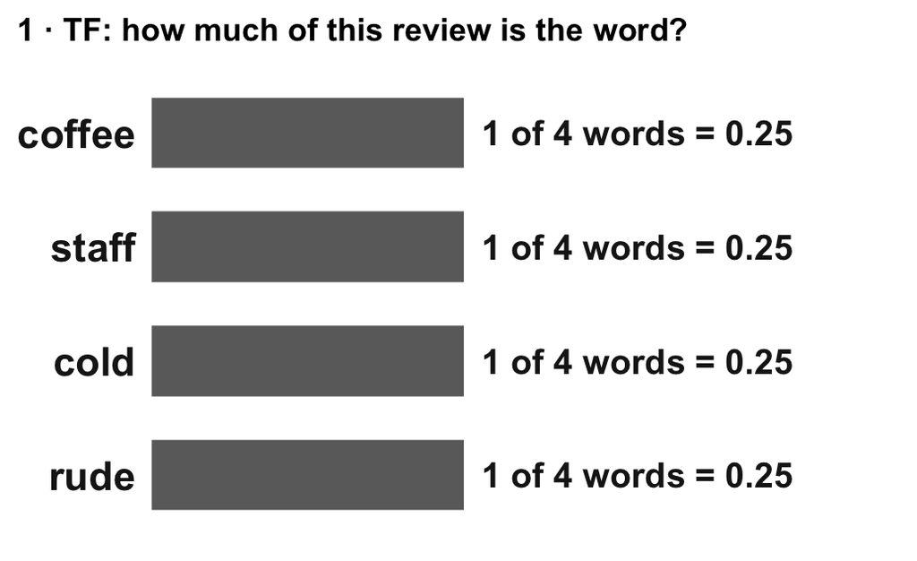

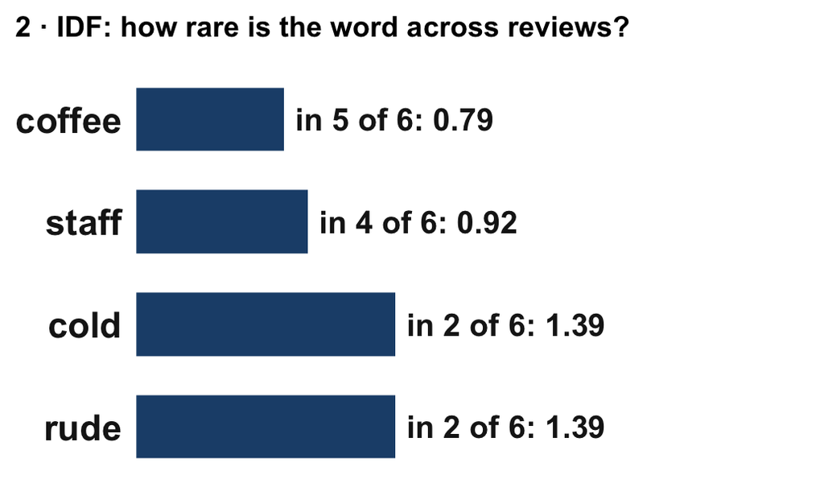

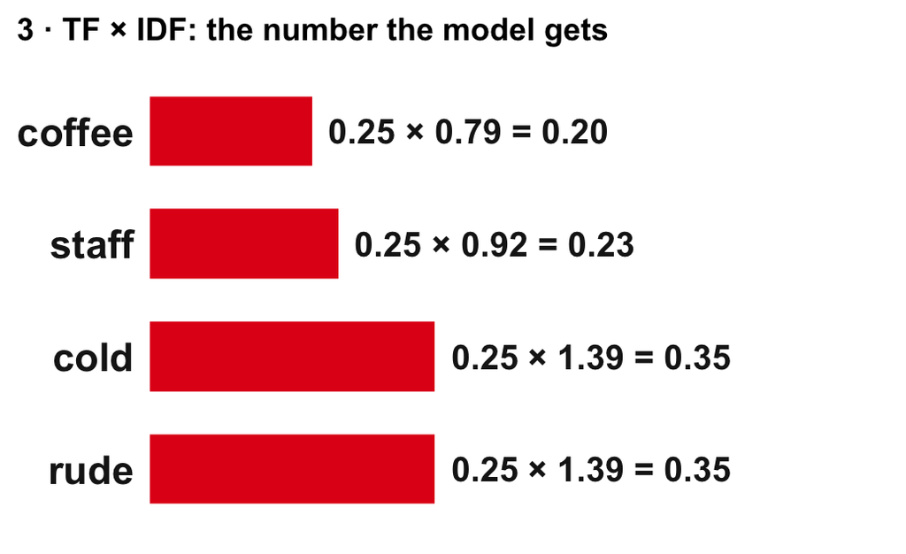

Four words, each used once. Which say most about **this** review?

TFcount ÷ words in the review term frequency

IDFlog(1 + reviews ÷ reviews with the word) inverse document frequency

TF-IDFTF × IDF

Common everywhere = worth less *coffee* is in 5 of 6 reviews, *rude* in 2. Same count, but *rude* gets the larger number.

IDF looks at all the reviews So it must be learned from the **training** reviews only: it goes **inside the recipe**, after the split.

## Split first, then the recipe

Text as dataI · Text to tableII · Which words?III · Predict, explainWrap-up

**Notebook** lines 226–256 the split chunk (239–243) is empty: type it · the recipe is given*code together*

nhs_rec <- recipe(positive ~ review_text, data = nhs_train) |> step_tokenize(review_text) |> step_stopwords(review_text, language = "en") |> step_tokenfilter(review_text, min_times = 10) |> step_tfidf(review_text)

1. **Outcome ~ predictor**: one predictor, the raw text.
2. **Cut into tokens**: `tokens()` in Part I.
3. **Drop stopwords**: `tokens_remove()`.
4. **Keep frequent words**: `dfm_trim()`.
5. **Count and weight**: `dfm()`, then TF-IDF.

```r
set.seed(123)
nhs_split <- initial_split(nhs_model_data,
               prop = 0.75, strata = positive)
nhs_train <- training(nhs_split)  # 1,489 reviews
nhs_test  <- testing(nhs_split)   #   497 reviews
```

How many columns come out? **100**, not 1,000. `step_tokenfilter()` also has `max_tokens`, default 100: only the 100 most used words stay.

## The model: boosted trees, again

Text as dataI · Text to tableII · Which words?III · Predict, explainWrap-up

**Notebook** lines 258–287 the model and the workflow: given, ready to run*run together*

model <- boost_tree(mtry = 0.03, trees = 2000, learn_rate = 0.01) %>% set_mode("classification") %>% set_engine("xgboost", counts = FALSE) nhs_fit <- workflow() %>% add_recipe(nhs_rec) %>% add_model(model) %>% fit(data = nhs_train)

1. **Boosted trees**: Lab 5’s relay.
2. **Words offered** per split.
3. **2,000 small trees** in a row.
4. **Each adds 1%** of its fix.
5. **Yes or no** outcome.
6. **xgboost**; `mtry` is a share.

One tree asks about words “Is *thank* in the review? If not: is *told*?” Each answer leads to another question, then to a guess.

Boosting Every new tree works on the reviews the trees so far get wrong. Small steps (`learn_rate`), so many trees.

`mtry = 0.03` 3% of 100 words: each split may choose among **3** random words.

## What did the model learn? One review

Text as dataI · Text to tableII · Which words?III · Predict, explainWrap-up

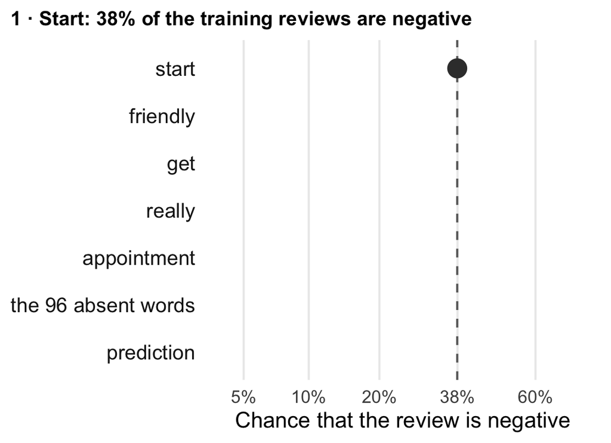

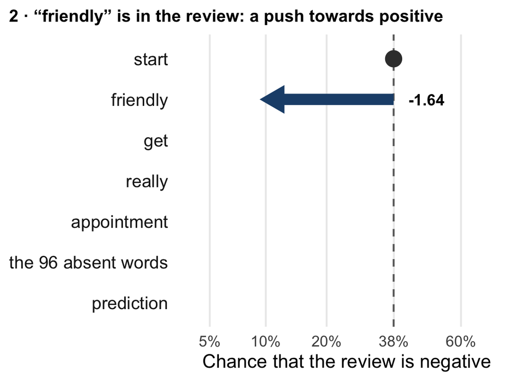

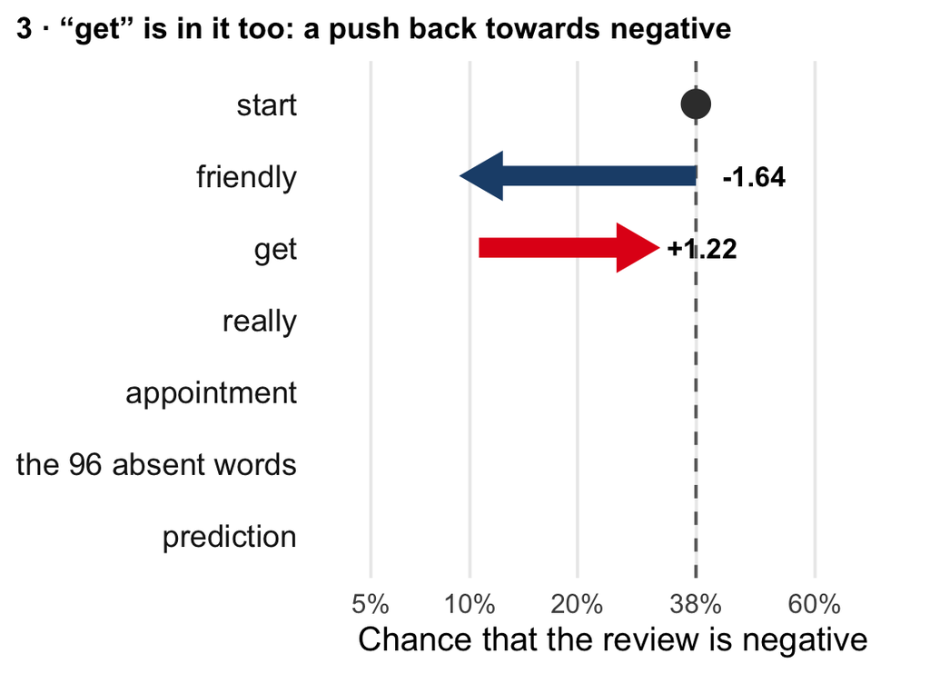

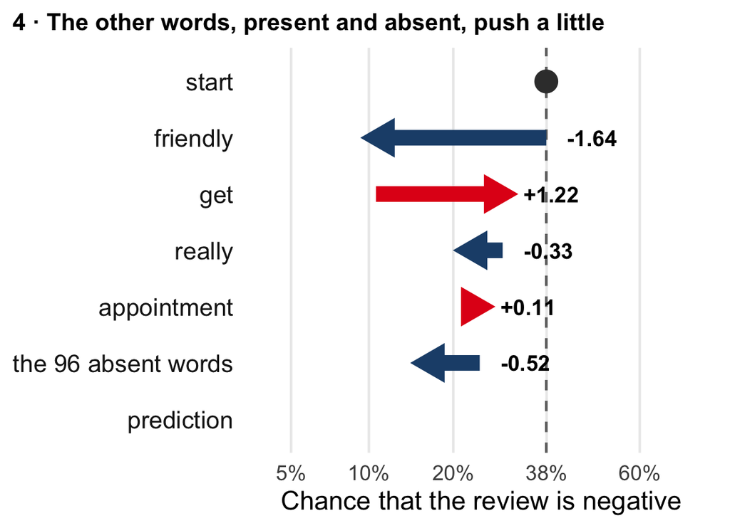

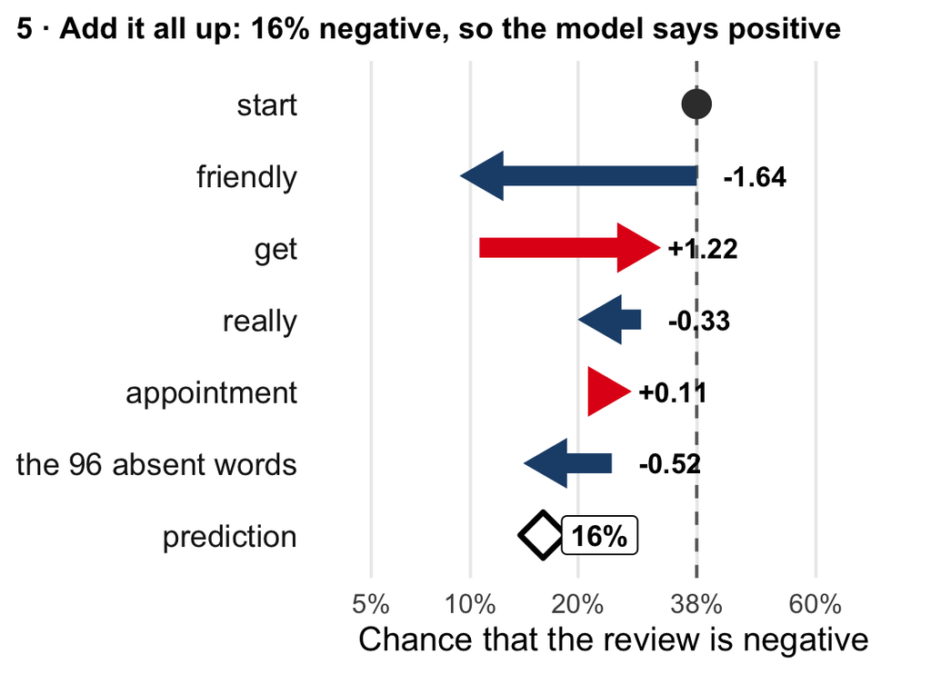

"Friendly, approachable, they listen instead of assuming, the only down side, it is really hard to get an appointment"

Positive or negative? Which words pull which way?

A SHAP value is one push How far did **this word** move the prediction for **this review**? Left: towards positive. Right: towards negative.

Start + pushes = prediction Exactly. SHAP explains the model one review at a time.

## Class discussion: read one SHAP value

Text as dataI · Text to tableII · Which words?III · Predict, explainWrap-up

**Notebook** lines 304–335 the SHAP chunk and its note*30 seconds with your neighbour*

In one review, the word “thank” has a SHAP value of −2.3. What does that mean?

**A**The word "thank" appears 2.3 times less often in this review than on average

**B**Having "thank" in this review moved the model's prediction a long way towards "positive"

**C**"thank" is an unimportant word, because its value is below zero

**D**Reviews that contain "thank" are 2.3% less likely to be negative

**B.** A SHAP value is a push on one prediction. The sign is the direction (below 0: away from "Negative"), the size is the strength. −2.3 is a large push: larger than "friendly" in the last example. Far from 0 in **either** direction means important.

## Your turn B: explain and evaluate

Part III · lines 289–388 · in pairs

1. **Lines 291–302:** finish the chunk: pipe the table into a bar chart of the 20 most important words.
2. **Lines 306–331:** run the SHAP chunk. Find “thank” and “told”: which side are their dots on?
3. **Line 337:** which words matter most? Which make sense, which surprise you?
4. **Lines 345–382:** run the confusion matrix and the F1 chunk. How many test reviews are wrong? Compare training and testing.
5. **Line 384:** how well does the model do? Name another model you could try.

Syntax you need

```r
nhs_fit |>
  vi() |>                          # importance per word
  slice_max(Importance, n = 20) |> # the top 20
  mutate(
    Variable = str_remove(Variable, "tfidf_review_text_"),
    Variable = fct_reorder(Variable, Importance)
  ) |>                             # add this pipe
  ggplot(aes(x = ___, y = ___)) +
  geom_col()                       # bars
```

- `vi()` returns two columns: `Variable` and `Importance`
- `fct_reorder()` sorts the bars by importance
- SHAP plot: one dot per review; colour = how much of the word
- Confusion matrix: rows are predictions, columns the truth

**Stuck?**

- `unexpected symbol`: the `|>` after `mutate( … )` is missing
- Bars in alphabetical order: `Variable` goes on `y`, after the `mutate()`

## Answers B: which words matter?

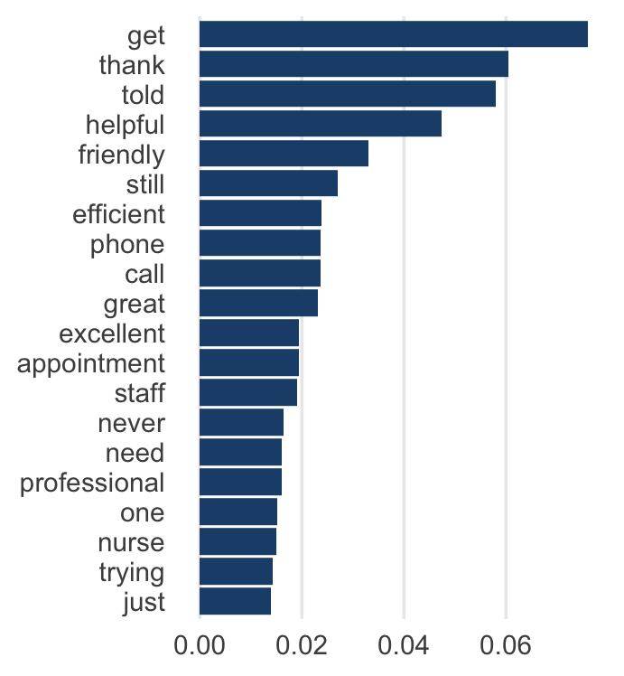

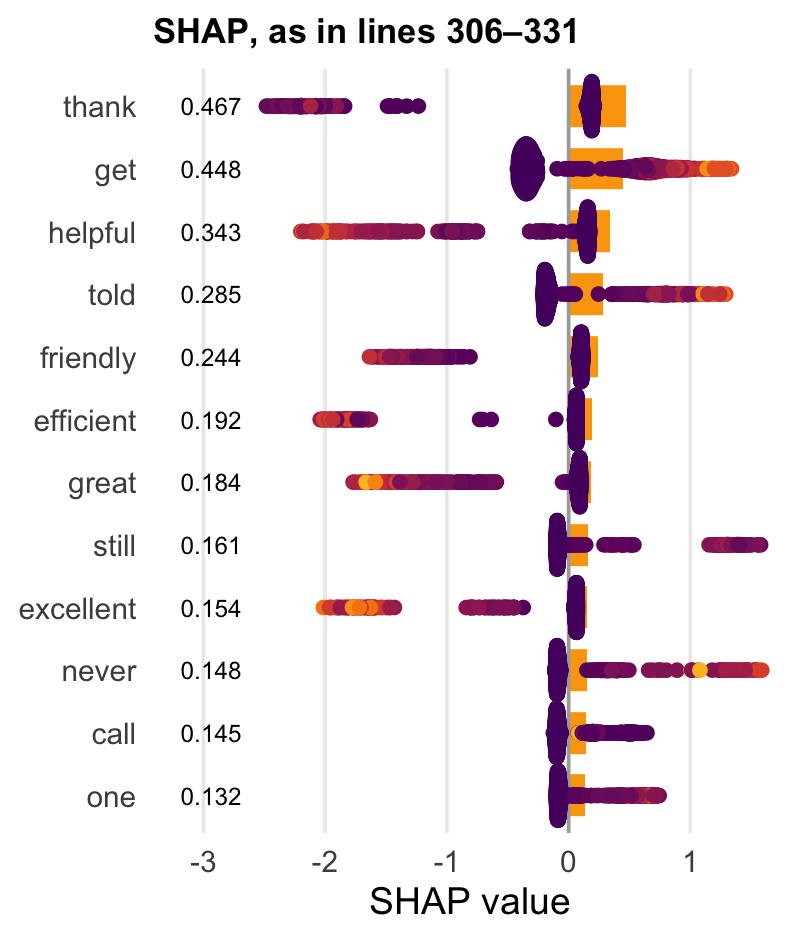

```r
... |>
  ggplot(aes(Importance, Variable)) +
  geom_col()
```

The same words on top *get, thank, told, helpful, friendly*: Part II’s words.

SHAP adds direction *thank*, *helpful*: dots far **left**, towards positive. *get*, *told*: **right**.

Less obvious *one*, *just*: no topic, but part of how a complaint is told.

## Answers B: how good is it?

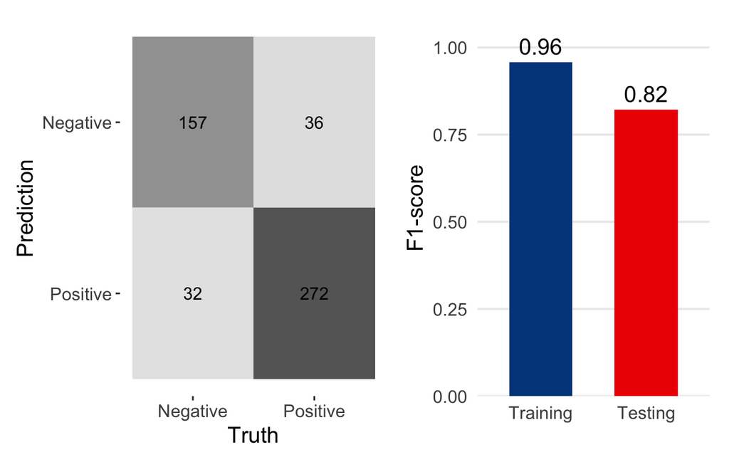

`f_meas()` scores the **first** level, “Negative”: how well does the model find the complaints? For “Positive” the test F1 is 0.89.

68 of 497 test reviews wrong 32 complaints called positive, 36 positive reviews called negative. From 100 words and no word order.

0.96 in training, 0.82 in testing The gap is **overfitting**: 2,000 trees have partly memorised the training reviews. The test score is the honest one.

Another model? A lasso logistic regression (Lab 3 and 4) on the same recipe: F1 0.80. Nearly as good, and its coefficients can be read.

## Summary

Text as dataI · Text to tableII · Which words?III · Predict, explainWrap-up

**1****Text becomes a table** in four steps: corpus, tokens, cleaning, counts. One row per document, one column per word: a **document-feature matrix**. Word order is lost, and every cleaning step is a choice. In code: `corpus()`, `tokens()`, `tokens_remove(stopwords("en"))`, `dfm()`, `dfm_trim()`

**2****Keyness** compares where a word is used with an even split: which words are typical of one group? **TF-IDF** weights a count down when the word is in most documents. In code: `textstat_keyness()`, `step_tfidf()`

**3****The model is Lab 5's**: split, recipe, boosted trees, F1 on the test set. Text steps go **inside the recipe**. **SHAP** explains it one review at a time: a start, a push per word with a direction, and they add up to the prediction

**Question:** a new review says “Not helpful at all.” What does the model see, and what will it probably predict? What would you change?

## Further reading

- The completed notebook goes up after class.
- [quanteda tutorials](https://tutorials.quanteda.io): corpus, tokens and DFM step by step, with the same functions as today.
- [*Supervised Machine Learning for Text Analysis in R*](https://smltar.com) (Hvitfeldt and Silge): chapters 2–3 on tokens and stopwords, chapter 7 on classification with `textrecipes`. Free online.
- [*Text Mining with R*](https://www.tidytextmining.com) (Silge and Robinson): chapter 3 on TF-IDF, chapter 4 on bigram networks. Free online.
- [*Interpretable Machine Learning*](https://christophm.github.io/interpretable-ml-book/) (Molnar): the chapters on Shapley values and SHAP.

## 30 seconds of feedback

[figure not shown]

How was today’s lab? Scan the code, or open forms.gle/i3uobCAaGmkzf1ns7. It takes 30 seconds and changes what next week looks like.